# Modelado de la probabilidad de ignición

Pere Gelabert

Universitat de Lleida

## Carga de librerías

En **R**, una **librería** (también llamada **paquete** o *package*) es un conjunto de **funciones, datos y documentación** que amplían las capacidades básicas del lenguaje.

En otras palabras:  
👉 Una librería en R es un **módulo adicional** que puedes instalar y cargar para realizar tareas específicas. Se instalan una primera vez con el comando `install.package("nombre"),` en sucessivas ocasiones solo hay que cargarlas con el comando `library()` como se muestra a continuación.

## Carga de librerías

```r
library(caret)
library(tidyverse)
library(sf)
library(terra)
library(pROC)
library(performance)
library(tmap)
library(broom)
library(ape)
library(knitr)

set.seed(123)
```

# Generación del dataset de igniciones

## Muestra de presencia

```r
# Cargamos los puntos de ignición de la EGIF
# y filtramos para que solo queden incendios mayores a 10 hectárea
PI <- st_read("./ps4/imputs/ignitions/BCN_HumanIgnitions.gpkg", quiet=T) %>%
  filter(Area_ha>10) %>%
  mutate(ignition=factor("x1")) %>% # Añadimos columna categórica para presencia
  select(ignition)%>%
rename(geometry=geom)
```

## Área de interés

```r
# Cargamos el shapefile del Área de Estudio (AOI)
AOI <- st_read("./ps4/imputs/ignitions/BCN_prov.gpkg", quiet=T)

# Probar tmap_mode("view") para generar un mapa interactivo y tmap_mode("plot") para
# un mapa estático
tmap_mode("view")

# Visualizamos los puntos de ignición dentro del AOI
tm_shape(PI[AOI,])+
  tm_dots()
```

[interactive chart not shown]

## Carga de las variables explicativas

```r
# Carga de variables explicativas
vars <- rast(list.files("./ps4/imputs/predictors/", full.names=T)) %>%
crop(.,AOI)
```

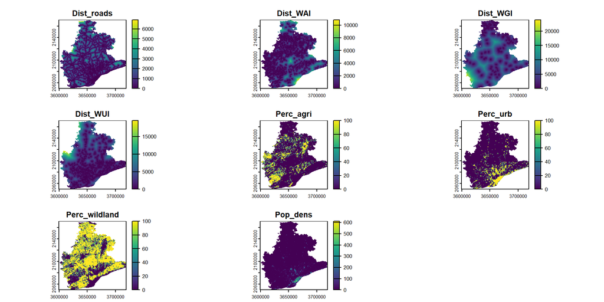

```r
plot(vars)
```

## Máscara de no combustible

Máscara para eliminar, cultivos de regadío, zonas urbanas, infraestructuras…

```r
mask_vect <- st_read("./ps4/imputs/No_fuelMask.gpkg", quiet=T)
```

### Generación muestra ausencia

Generamos zonas candidatas para ausencia (a 500m de puntos de ignición y fuera de las zonas sin combustible)

```r
AOIno <- st_difference(AOI,PI %>%
                         st_buffer(500) %>%
                         st_union()) %>%
 st_difference(., mask_vect %>% filter(ModelsComb==2)) %>%
  st_filter(AOI)
```

### Ubicación de aleatoria de puntos de ausencia

Estos se ubican en las geometrias definidas anteriormente, es decir, a 500m de puntos de ignición y fuera de las zonas sin combustible.

```r
# Creamos puntos de ausencia aleatorios (tantos como presencia)
NO_PI <-  st_sample(AOIno, size=nrow(PI) ,type="random") %>%
  st_as_sf() %>%
  mutate(ignition=factor("x0")) %>%
  rename(geometry=x)
```

```r
# Mapa comparando puntos de presencia y ausencia
tmap_mode("view")

  tm_shape(NO_PI)+
    tm_dots("green")+
      tm_shape(PI)+
        tm_dots("red")
```

[interactive chart not shown]

### Dataset definitivo de ausencia y presencia

Combinamos los puntos de presencia y ausencia; además de extraer los valores de las variables explicativas, almacenadas en formato ráster.

```r
PI_df <- bind_rows(PI,NO_PI) %>%
  bind_cols(tibble(terra::extract(vars,.))) %>%
  select(-ID) %>%
  mutate(ignition=factor(ignition,labels=c("x1","x0"))) %>%
  drop_na()
```

# Modelado

## Muestra entrenamiento y validación

```r
# Separación en conjuntos de entrenamiento y test
train <- PI_df %>% sample_frac(.8)
test <- PI_df %>% anti_join(train %>% st_drop_geometry())

# Convertimos la variable dependiente a binaria (0 = ausencia, 1 = presencia)
train_logit <- train%>%
  mutate(y=case_when(ignition=="x0"~0,
                     ignition=="x1"~1)) %>%
  select(-ignition) %>% st_drop_geometry()

test_logit <- test%>%
  mutate(y=case_when(ignition=="x0"~0,
                     ignition=="x1"~1)) %>%
  select(-ignition)
```

## Entrenamiento del modelo logístico

```r
# Entrenamiento de un modelo logístico simple
logit <- glm(y~.,data=train_logit, family=binomial(link="logit"))
summary(logit)
```

```
Call:
glm(formula = y ~ ., family = binomial(link = "logit"), data = train_logit)

Coefficients:
                Estimate Std. Error z value Pr(>|z|)
(Intercept)   -0.1129076  1.8654715  -0.061   0.9517
Dist_roads     0.0006515  0.0004335   1.503   0.1329
Dist_WAI      -0.0002174  0.0004269  -0.509   0.6107
Dist_WGI       0.0001669  0.0001061   1.573   0.1158
Dist_WUI      -0.0001146  0.0001633  -0.702   0.4829
Perc_agri      0.0021367  0.0180114   0.119   0.9056
Perc_urb      -0.0812478  0.0505699  -1.607   0.1081
Perc_wildland -0.0228921  0.0165217  -1.386   0.1659
Pop_dens       1.9800282  0.9816870   2.017   0.0437 *
---
Signif. codes:  0 '***' 0.001 '**' 0.01 '*' 0.05 '.' 0.1 ' ' 1

(Dispersion parameter for binomial family taken to be 1)

    Null deviance: 80.405  on 57  degrees of freedom
Residual deviance: 56.310  on 49  degrees of freedom
AIC: 74.31

Number of Fisher Scoring iterations: 7
```

## Predicción del modelo

```r
preds_logit <- test_logit %>%
    rename(Obs = y) %>%
bind_cols(predict(logit, test_logit,
                  type = "response") %>%
          as_tibble() %>%
          rename(Pred = 1)) %>%
    mutate(residual = Obs - Pred) %>%
    select(Obs,Pred,residual)
head(preds_logit)
```

```
Simple feature collection with 6 features and 3 fields
Geometry type: POINT
Dimension:     XY
Bounding box:  xmin: 3605480 ymin: 2060263 xmax: 3663520 ymax: 2126212
Projected CRS: ETRS89-extended / LAEA Europe
  Obs      Pred     residual                geometry
1   1 0.6636985 3.363015e-01 POINT (3652875 2117111)
2   1 0.6877484 3.122516e-01 POINT (3657136 2126212)
3   1 0.1945064 8.054936e-01 POINT (3611246 2111562)
4   1 1.0000000 2.586036e-08 POINT (3663520 2072024)
5   1 0.7760218 2.239782e-01 POINT (3605480 2087209)
6   1 1.0000000 2.220446e-16 POINT (3650587 2060263)
```

## Revisión de las asunciones del modelo

```r
check_model(logit)
```

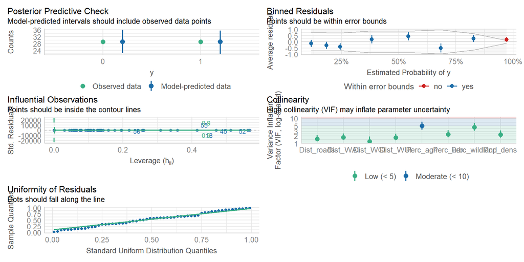

## Precisión

| Rango AUC | Calidad del modelo | Interpretación |
| --- | --- | --- |
| **0.9-1** | *Excelente* | *El modelo dicrimina casi a la perfección las clases* |
| **0.8-0.9** | *Buena* | *El modelo tiene una buena capacidad de discriminación* |
| **0.7-0.8** | *Aceptable* | *Discriminación moderadamente buena* |
| **0.6-0.7** | *Pobre* | *Discriminación débil* |
| **0.5-0.6** | *Mala* | *EL modelo no discrimina mejor que el azar* |

```r
ROC<- roc(preds_logit$Obs, preds_logit$Pred)
print(auc(ROC))
```

```
Area under the curve: 0.8776
```

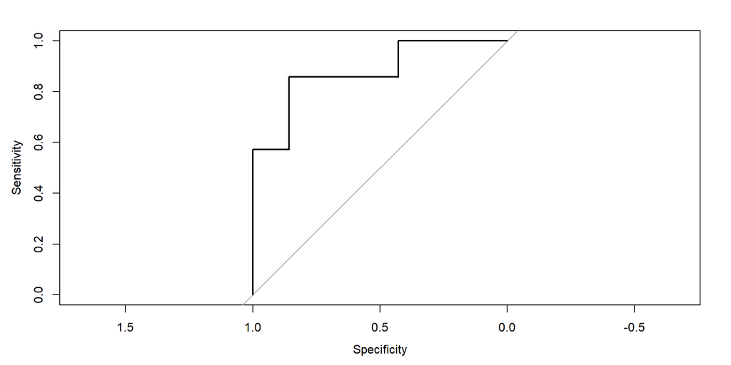

```r
plot(ROC)
```

## Importancia de variables

$$OR_i = e^{\beta_i}$$

```r
tabla_or <- broom::tidy(logit) %>%
  filter(term != "(Intercept)") %>%        # quitar intercepto
  mutate(
    OR = exp(estimate),                    # calcular e^beta
    Signo = ifelse(estimate >= 0, "+", "-") # signo del coeficiente
  ) %>%
  arrange(desc(OR)) %>%                    # ordenar de mayor a menor
  select(Variable = term, Coeficiente = estimate, OR, Signo)
```

Coeficientes y Odds Ratios

| Variable | Coeficiente | OR | Signo |
| --- | --- | --- | --- |
| Pop_dens | 1.98002817 | 7.2429470 | + |
| Perc_agri | 0.00213669 | 1.0021390 | + |
| Dist_roads | 0.00065153 | 1.0006518 | + |
| Dist_WGI | 0.00016692 | 1.0001669 | + |
| Dist_WUI | -0.00011459 | 0.9998854 | - |
| Dist_WAI | -0.00021736 | 0.9997827 | - |
| Perc_wildland | -0.02289213 | 0.9773679 | - |
| Perc_urb | -0.08124782 | 0.9219652 | - |

## Random forest

```r
hiperparametros <- expand.grid(mtry = c(2,3,4),
                               min.node.size = c(10,20,40,60,100),
                               splitrule = "gini")

control_train <- trainControl(method = "repeatedcv",
                              number = 5,
                              repeats = 3,
                              verboseIter = TRUE,
                              classProbs = TRUE,
                              summaryFunction = twoClassSummary)


RF <- train(ignition ~ .,
                  data = train %>% drop_na() %>% st_drop_geometry(),
                  method="ranger",
                  tuneGrid = hiperparametros,
                  metric = "ROC",
                  importance = "impurity",
                  trControl = control_train,
                  num.trees = 1500)
```

### Importancia de variables

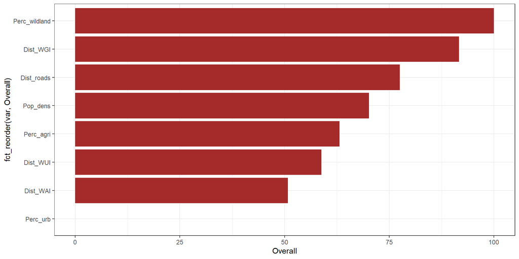

```r
varImp(RF)$importance%>%
data.frame()%>%
rownames_to_column("var")%>%
ggplot()+
geom_col(aes(x=Overall,y=fct_reorder(var,Overall)), fill="brown")+
theme_bw()
```

### Predicción del modelo

```r
preds_RF <- test %>%
    mutate(ignition= ifelse(ignition=="x0",0,1)) %>%
    rename(Obs = ignition) %>%
bind_cols(predict(RF, test,
                  type = "prob") %>%
          as_tibble() %>%
          rename(Pred = 1) %>%
         select(Pred)) %>%
    mutate(residual = Obs - Pred) %>%
    select(Obs,Pred,residual)
head(preds_RF)
```

```
Simple feature collection with 6 features and 3 fields
Geometry type: POINT
Dimension:     XY
Bounding box:  xmin: 3605480 ymin: 2060263 xmax: 3663520 ymax: 2126212
Projected CRS: ETRS89-extended / LAEA Europe
  Obs      Pred  residual                geometry
1   1 0.6743972 0.3256028 POINT (3652875 2117111)
2   1 0.6803606 0.3196394 POINT (3657136 2126212)
3   1 0.4546015 0.5453985 POINT (3611246 2111562)
4   1 0.7007590 0.2992410 POINT (3663520 2072024)
5   1 0.7497038 0.2502962 POINT (3605480 2087209)
6   1 0.6650442 0.3349558 POINT (3650587 2060263)
```

## Validación

```r
ROC<- roc(preds_RF$Obs, preds_RF$Pred)
print(auc(ROC))
```

```
Area under the curve: 0.9796
```

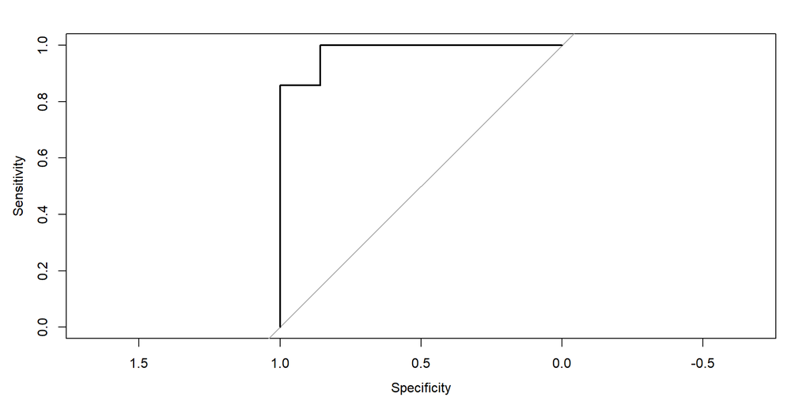

```r
plot(ROC)
```

## PDPs

```r
listPdp=list()
library(pdp)
variables <- RF$coefnames

  for(var in variables){


      listPdp[[length(listPdp)+1]] <- partial(RF, pred.var=var, prob=T) %>%
        as_tibble()


}
```

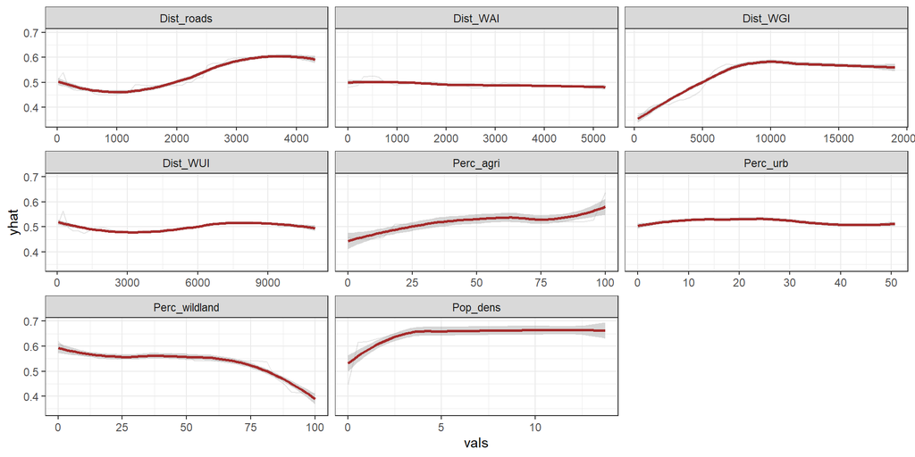

```r
map(listPdp,~pivot_longer(.x,!c(yhat), names_to = "var", values_to = "vals")) %>%
  bind_rows() %>%
  ggplot()+
  geom_line(aes(x=vals,y=yhat), alpha=0.1)+
  geom_smooth(aes(x=vals,y=yhat), color="brown")+
  facet_wrap(.~var, scales="free_x")+
  theme_bw()
```

## PdP modelo logit y comparación

*Ahora vosotr@s!*

- Calcular y graficar los PdPs del modelo logit.

## Independencia

Los residuos no deben tener autocorrelación espacial ni temporal.

e.g.: Temperatura

- No hace falta medirla en un transecto cada metro ni cada segundo..

### Autocorrelación espacial

**I de moran**

$$I = \frac{N}{W} \cdot
\frac{\sum_{i}\sum_{j} w_{ij}(x_i - \bar{x})(x_j - \bar{x})}
{\sum_{i}(x_i - \bar{x})^2}$$

where:

Como se evalua:

| Hipótesis | Descripción | Interpretación |
| --- | --- | --- |
| $H_0$ | No hay autocorrelación espacial | *Distribución aleatoria* |
| $H_1$ | Hay autocorrelación espacial | *Agregaciones espaciales (+ o -)* |

Si $pvalor>0.05$ **No se rechaza** $H_0$,

Si $pvalor<0.05$ **se rechaza** $H_0$ **y se acepta** $H_1$

```r
dist_preds <- st_distance(preds_RF) %>% units::drop_units()
dist_preds_inv = 1/dist_preds
diag(dist_preds_inv) <- 0

Moran.I(preds_RF$residual, dist_preds_inv)
```

```
$observed
[1] -0.1442599

$expected
[1] -0.07692308

$sd
[1] 0.09133746

$p.value
[1] 0.460982
```

```r
dist_preds <- st_distance(preds_logit) %>% units::drop_units()
dist_preds_inv = 1/dist_preds
diag(dist_preds_inv) <- 0

Moran.I(preds_logit$residual, dist_preds_inv)
```

```
$observed
[1] -0.1059894

$expected
[1] -0.07692308

$sd
[1] 0.08243555

$p.value
[1] 0.7243925
```

## Predicción espacial

```r
plot(vars)
```

[output not shown]

```r
pred_logit <- predict(vars,logit, na.rm=T, type="response")%>% mask(mask_vect %>% filter(ModelsComb==1))
pred_RF <- predict(vars,RF, na.rm=T, type="prob")%>% mask(mask_vect %>% filter(ModelsComb==1))
```

```
Aggregating predictions.. Progress: 31%. Estimated remaining time: 1 minute, 8 seconds.
Aggregating predictions.. Progress: 73%. Estimated remaining time: 22 seconds.
```

[figure not shown]

```r
plot(pred_RF)
```

```r
pred_RF<- pred_RF$x1
```

[figure not shown]

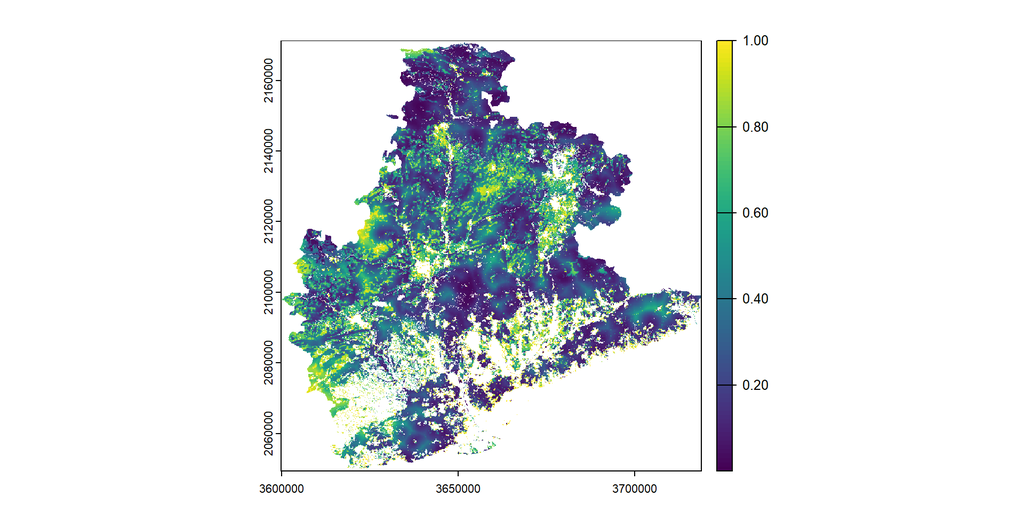

```r
plot(pred_logit)
```

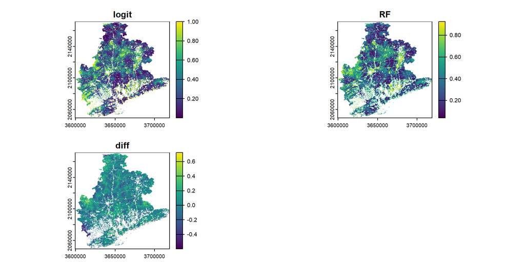

```r
preds <- c(pred_logit,pred_RF,(pred_RF-pred_logit))
names(preds) <- c("logit","RF","diff")
plot(preds)
```